# Notes

# About

These are class notes and R code for Dorcas Ofori-Boaten’s STAT-461 : Introduction to Statistics I for Fall term 2021 at Portland State University.

# W1-D1 : Tues. Sept. 28, 2021

- Dorcas or Professor Dorcas
- first of series of three courses
- originally from Ghana (small country)
- passion and drive for math and analysis
- goal of all classes is academic **excellence**
- send email anytime of day to doforib2@pdx.edu
- please read through syllabus
- first homework will be assigned on Thursday and due the following Thurseday
- due dates will switch to Tuesday after the midterm
- extra credit can be carried onto something in the future if it isn’t needed on direct homework
- some extra credit will be in the slides (pay attention)
- homework due at 11:5PM (wont work at 12:00)

## Chapter 1 : What is Statistics?

- statistics is applied math which allows you to study data to form a judgment in a case of real world applications.
- have discipline that is math related, but more applied in it’s focus
- get data, then summary or form of information from that data
- real world scenarios aren’t fixed or absolute
- in collection of data there is variability, but we are still able to capture the variability (that is the endtails of statistics)
- When you say something is average, you are saying it with some confidence
- random errors also have to be continuous

### Population , Sample, Census

| Parent | Child | Example |
| --- | --- | --- |
| Population : well defined collection of objects in a study (focus of the study) | Parameter | all PSU Student |
| Sample : smaller portion of population that reflects population | Statistic | sample of students |
| Census : all desired information of a population |  |  |

- the first letter of each of these goes back to the parent
- Example: Difference between rookie salaries between Yankee and Marlon players.
  - What are the collection of objects for this study? (aka the **the population**)
    - The entire collection of people, who include all Yankee players and all Marlon players
- a **sample** is a smaller portion of the population used to predict the nature of the entire population
  - there are different ways to sample different schemes
  - make sure the sample is a true reflection of the structure of the population
- the **census** is when you go into population and collection all desired information person by person (or object to object)
  - list of desired information is know as a **census**

| Types | Defintition | Methods |
| --- | --- | --- |
| Descriptive | allow the methods to calculate summaries (mean, variance, ect.) | graphical (histogram on) and numerical |
| Inferential | want to infer, predict what will happen next |  |

- once able to describe sampel and move it onto the population you are moving into inferential population

### Descriptive Statistics

- for graphical methods looks at ..
1. the center
2. the variation
3. the distribution $\frac{a_{1}+a_{2}+a_{3}+...+a_{n}}{n}$
4. time
5. outliers
- histogram is bars laid side by side to show data in a study

### Skew

- left skew, right skew, and symmetric distribution

| skew | definition |
| --- | --- |
| Right Skew | data is on the left with gradation will decreasing to the right |
| Left Skew | tallest bar will be to the right and gradion will be to the left |
| Symmetric | equibalance state, where the tallest bar is in the middle and divides the data into two equal parts |

- for a normal distribution mean, median, and mode are the same thing
- based on skewness you can tell where mean will fall
- other graph patterns : U shape, uniform, Binodal (two bumps), bell-shaped

### Mean

- Population Mean : $\mu=\frac{x_{1}+x_{2}+x_{3}+...+x_{n}}{N}$
- Sample Mean : $\overline{x}=\frac{x_{1}+x_{2}+x_{3}+...+x_{n}}{n}$
- Sample Mean (textbook) : the sample mean , “y-bar”, of *n* measured responses $y_{1},y_{2},...,y_{n}$

$$\overline{y}=\frac{1}{n}\sum_{i=1}^{n}y_{i}$$

- the mean is sensitive to outliners (not robust)
- the mean is not an accurate value to give on its own.
- trimmed mean doesn’t mean you throw away, you simply compute the mean you are intrested in

### Median

- sample median : $\widetilde{x}$
- to find the median : order the data from smallest to largest and find the value in the middle
  - if total number of population or sample is even then will need to take the two middle values and divide them by 2.
- median is robust to outliers, because the center will still be the center regardless
- advisable to use the route of median for summaries
- to find the median : order the data set and find the value in the middle

### Mode

- highest frequency
- value that has appeared the highest number of times
- mode is essential descriptor for data

### Range

Max - Min

### Variance and Standard Deviation

- Population Variance : $\sigma ^{2}=\frac{[(x_{1}-\mu)^{2}+(x_{2}-\mu)^{2}+...(x_{n}-\mu)^{2}]}{N}=\frac{(x_{i}-\overline{x})^{2}}{N}$
- Population Standard Deviation : $\sigma=\sqrt{\sigma^{2}}$
- Sample Variance : $s^{2}=\frac{[(x_{1}-\overline{x})^{2}+(x_{2}-\overline{x})^{2}+...(x_{n}-\overline{x})^{2}]}{n}=\frac{(x_{i}-\overline{x})^{2}}{n}$
- Sample Variance (textbook) :
  $$s^{2}=\frac{1}{n-1}\sum_{i=1}^{n}(y_{i}-\overline{y})^{2}$$
- Sample Standard Deviation : $s=\sqrt{s^{2}}$

### Summary

# W1-D2 : Thur. Sept. 30, 2021

$\Rightarrow$ Review from last class :

- Characterizing a Set of Measurements : Graphical Methods
  - Distribution Patterns : U Shape, Uniform, Bimodal, Bell-Shape (Normal)
  - Symmetry (balancing in the middle), right skewed (mean to the right of data), left skewed (mean to the left of data)
  - Histograms can be used with frequency, relative frequency or percentage.
- Characterizing a Set of Measurements : Numerical Methods
  - Mean (average)
    - Sample Mean : $\overline{y}=\frac{1}{n}\sum_{i=1}^{n}y_{i}$
    - Population Mean : $\mu =\frac{1}{N}\sum_{i=1}^{N}Y_{i}$
    - Mean is sensitive to outliers because it uses every data value
  - Median (middle value)
    - Median is not sensitive to outliers because it only looks at middle values
    - For even data sets the mean of the two middle values is the median
  - Mode (appears most frequently)
  - Range (Max - Min)
    - sensitive to outliers
  - Variance (avg. **squared** deviation of data from mean)
    - Population Variance : $\sigma^{2}=\frac{1}{N}\sum_{i=1}^{N}(Y_{i}-\mu)^{2}$
    - Sample Variance : $s^{2}=\frac{1}{n-1}\sum_{i=1}^{n}(y_{i}-\overline{y})^{2}=\frac{1}{n-1}[\sum_{i=1}^{n}y_{i}^{2}-n\overline{y}^{2}]$
    - sensitive to outliers
  - Standard Deviation (avg. deviation of data from mean)
    - Population Standard Deviation : $\sigma=\sqrt{\sigma^{2}}$
    - Sample Standard Deviation : $s=\sqrt{s^{2}}$
    - Approximate Sample : $s\approx \frac{\text{Range}}{4}$
    - sensitive to outliers
  - Smaller variance or standard deviation indicates that the data are more consistent

### Examples

**In class** : Given a random sample of 10 observations such that the sample mean is 5 and $\sum_{i=1}^{n}y_{i}^{2}=350$. Compute the sample standard deviation. (Hint use the shortcut formula)

Given $n=10$ and $\overline{y}=5$ the sample standard deviation is :

$$\begin{equation} \label{a}
\begin{split}
s & = \sqrt{\frac{1}{n-1}[\sum_{i=1}^{n}y_{i}^{2}-n\overline{y}^{2}]}\\
& = \sqrt{\frac{1}{10-1}[350-(10*5^{2})]}\\
& = \sqrt{\frac{100}{9}}\\
& = 3.33
\end{split}
\end{equation}$$

**Example 11** : Listed below are the distances (in kilometers) from a home to local supermarkets.

```r
data <- c(1.1, 4.2, 2.3, 4.7, 2.7, 3.2, 5.6, 3.3, 3.5, 3.8, 4.0, 1.5, 4.5, 4.5, 2.5, 4.8, 3.3, 5.5, 6.5, 12.3)
data
```

```
##  [1]  1.1  4.2  2.3  4.7  2.7  3.2  5.6  3.3  3.5  3.8  4.0  1.5  4.5  4.5  2.5
## [16]  4.8  3.3  5.5  6.5 12.3
```

1. Compute the Range (12.3-1.1)

```r
range <- max(data)-min(data)
range
```

```
## [1] 11.2
```

2. Approximate the standard deviations using the range

$s\approx \frac{\text{Range}}{4}=\frac{11.2}{4}=2.8$

3. The following output shows numerical summaries obtained with the R package pastecs.

```r
library(pastecs)
stat.desc(data)
```

```
##      nbr.val     nbr.null       nbr.na          min          max        range
##   20.0000000    0.0000000    0.0000000    1.1000000   12.3000000   11.2000000
##          sum       median         mean      SE.mean CI.mean.0.95          var
##   83.8000000    3.9000000    4.1900000    0.5238973    1.0965297    5.4893684
##      std.dev     coef.var
##    2.3429401    0.5591743
```

Why do you think the computed s (2.343) is slightly smaller than the approximated value in part (b)?

Simple, becauase part(b) is an approximation.

### The Empirical Rule

When the data is bell-shaped (normally distributed) then the **Empirical Rule** can be used to find the percentage of the data with 1, 2, or 3 standard deviations about the mean.

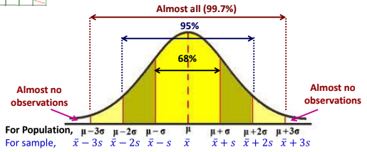

- first use the **Empirical Rule** to find out the number of standard deviations (z) correspond to bounds of interval
- next transfer z to data value (y) of variable using the following formula

Data Value = Mean + z*Standard Deviation

- sample : $y=\overline{y}+zs$
- population : $Y=\mu +z\sigma$

### Summary

- Review descripitive statistics including examples
- The Empirical Rule : 68-95-99.7

# W2-D3 : Tues. Oct. 5, 2021

- moving into chapter 2 which deals with more probability
- review empirical rule

### Examples

**Example** : Resting breathing rates for college-age students are approximately normally distributed (bell-shaped) with mean 12 and standard deviation 2.3 beaths per minute.

1. What percentage of students have between 9.7 and 14.3 breaths per minute?

$z_{1}=\frac{y-\overline{y}}{s}=\frac{9.7-12}{2.3}=-1$

$z_{2}=\frac{14.3-12}{2.3}=1$

Accoding to the empirical rule, about 68% of students have breath rate within 1 standard deviaiton of the mean.

2. What percentage of students have less than 7.4 breaths per minute?

$z=\frac{7.4-12}{2.3}=-2$

$\frac{100-95}{2}=2.5\%$

2.5% of students have brath rates less than 7.4 breaths per minute.

### Probability

What is probability?

**Probability** refers to the study of randomness and uncertainty.

- Probability indicates how likely it is for something to occur in a random experiment. For example, how likely or what is the chance that if you roll a fair 100-sided die (slides labeled 1 through 100), how likely you observe 65 on the top.

An **experiment** is any activity / process whose outcome s is subject to uncertainty.

- Toss a coin, Roll a Die once or twice.

A **sample space** is the set of all possible outcome of a random experiment. Denoted by S.

- Toss a coin once $S=\{\text{heads, tails}\}$

An **event** is a subset (small collection of outcomes) of sample space and denoted by capital letter. Event and set are interchangeable.

- What are the outcomes with at least one head when a coin is tossed twice?

$S=\{\text{HH, HT, TH, TT}\}$ $A=\{\text{HT,TH}\}$

- If an event has only a single point, then it is a simple event. Otherwise it is a compound event.

The **Null set (empty event)** is an event with no elements. Denoted $\emptyset$ or $\{\}$.

### Set Theory Notation

The **complement** of an event A is the set of all outcomes in the sample space that do not belong to A. Denoted : $A^{c}$, $A'$ or $\overline{A}$.

The **intersection** of two events A and B. The collection of all outcomes that appear in both A AND B. Denoted : $A\cap B$

- $A\cap B=B\cap A$

The **union** of two events A and B. The collection of all outcomes that appear in either A OR B OR in both. Denoted : $A\cup B$

Event B is a **subset** of Event A if **every** element of B is also in A. This is denoted by $B\subset A$

If $A\cap B=\emptyset$, then A and B are **disjoint** or **mutually exclusive** events.

$A_{1}, A_{2},...,A_{n}$ are **exhaustive** events if and only if $A_{1}\cup A_{2}\cup ...\cup A_{n}=S$

$A_{1}, A_{2},...,A_{n}$ are pairwise **mutually exclusive (dijoint)** and **exhaustive** events :

1. if and only if $A_{1}\cap A_{j}=\emptyset \forall i\ne j$

AND

2. $A_{1}\cup A_{2}\cup ...\cup A_{n}=S$

### Basic Properties

$A\cap \emptyset = \emptyset$

$A\cup \emptyset =A$

$A\cap \overline{A}=\emptyset$

$A\cup \overline{A}=S$

$\overline{S}=\emptyset$

$\overline{(\overline{A})}=A$

### DeMorgan’s Law

$(\overline{A\cap B})=\overline{A}\cup \overline{B}$

$(\overline{A\cup B})=\overline{A}\cap \overline{B}$

### Distributive Law

$A\cap (B\cup C) = (A\cap B)\cup (A\cap C)$

$A\cup (B\cap C) = (A\cup B)\cap (A\cup C)$

### Probability

- probability of an event $A:P(A)$

$$P(A)=\frac{\text{count(numbers) of outcomes in event A}}{\text{count (number) of outcomes in the sample space}}$$

Note : $0\leq P(A)\leq 1$

### Counting Rules

**Product rule for k-tuplets** : If a process can be broken down into a sequence of K steps, then the total number of possible outcomes is the product of the number of outcomes at each step.

- Suppose a license plate number is formed with 3 letters, followed by 3 numbers. How many different outcomes are possible? $26^{3}\cdot 10^{3}=17576000$

The **Factorial Rule** is the number of ways to order or rank or arrange n objects is $n!=n(n-1)(n-2)...(3)(2)(1)$.

Notes 0!=1, and 1!=1

The **Combination rule** has the following set up :

1. n different items are available
2. select k of the n items without replacement
3. order of selection does not matter

$${n\choose k}C={n\choose k}=\frac{n!}{k!(n-k)!}$$

Note : “n choose k”

- How many 5 element subsets are in the set S={2, 3, 4, 5, 6, 7, 8, 9}?

The **Permutation Rule** has the following set up :

1. n different items are available
2. Select k of the n items without replacement
3. Order of selection matter.

$${n\choose k}P=\frac{n!}{(n-k)!}$$

- There are ten candidates for a job. The search committee will choose four of them, and rank the chosen four from strongest to weakest. How many different outcomes are possible?

### Counting Rules : Summary

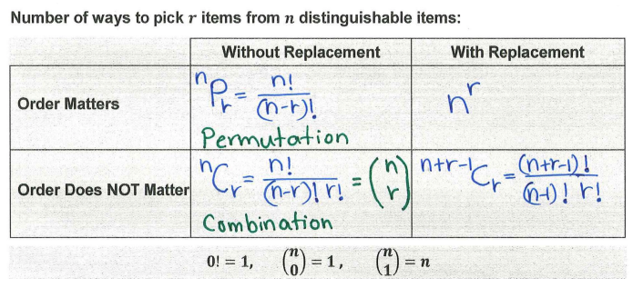

### More Examples

These are not extra credit, but try these to get counting technique down.

1. A fleet of 9 taxis is to be dispatched to 3 airports in such a way that 3 go to airport A, 5 go to airport B and 1 goes to airport C. In how many distinct ways can this be accomplished?

$^{9}C_3\times^{6}C_5\times^{1}C_1=84\times 6\times 1=504$

Using TI-84 : [MATH]$\Leftarrow$[PRB] 3: nCr

2. From a collection of 9 paintings, four are to be selected to hang side by side on a gallery wall in positions 1, 2, 3, and 4. In how many ways can this be done?

- because order matters

Using TI-84 : [MATH]$\Leftarrow$[PRB] 2: nPr

3. Suppose your iPod contains 5 albums, each with 10 songs. How many ways can a playlist of 4 songs be selected if a song can be repeated?

$(5\times 10)^4=6,250,000$

- we want to choose 4 songs out of 5 albums (50 songs) with replacement, and order matters.
4. A class consists of 19 students: 8 sophomores, 5 juniors, and 6 seniors. The instructor randomly selects a group of 6 students to present problems on the board. How many possible groups can be chosen?

$^{19}P_6=19,535,040$

- we want to choose 6 students out of 19 without replacement, and order matters.
5. A class consists of 19 students: 8 sophomores, 5 juniors and 6 seniors. The instructor randomly selects a group of 6 students to present problems on the board. How many possible groups can be chosen if the group must consist of 2 sophomores, 2 juniors, and 2 seniors?

$^{8}C_2\times^{5}C_2\times^{6}C_2=28\times 10\times15=4,200$

- we want to choose 2 out of 8 sophomores, 2 out of 5 juniors, and 2 out of 6 seniors without replacement, and order does not matter.

### Probability Examples

A student prepares an exam by studying a list of 10 problems. She can solve 6 of them. For the exam, the instructor selects 5 problems at random from the 10 on the list given to the students. What is the probability that the student can solve all 5 problems on the exam?

$\frac{^{6}C_5}{^{10}C_5}=\frac{6\choose5}{10\choose 5}=0.024$

- we want to see how many combinations are possible in the space, so it doesn’t matter how many the student can solve when calculating the denominator.

### Extra Credit

The college of liberal arts and sciences is made up of 12 freshmen, 10 sophomores, 7 juniors and 7 seniors. What is the probability of selecting a student from each group to form a student advisory council?

$\frac{^{12}C_1\times ^{1}C_1\times ^{7}C_1\times ^{7}C_1}{^{36}C_4}=\frac{5880}{58905}=0.099822$

Answer : ~9.98% rare likelihood

- we want to first choose 4 out of 36 students without replacements, and order doesn’t matter. P(B)
- then we want to choose 1 of the 12 freshman, 1 of 10 sophomores, 1 of 7 junors, and 1 of 7 seniors without replacements and order doesn’t matter. P(A)
- P(A)/P(B)

### Summary

- Homework 1 is due the end of day Thursday (completed)
- Email Extra Credit to Professor before class Thursday (completed)
- Today we did examples applying The Empirical Rule and the equation $z=\frac{y-\overline{y}}{s}$
- Went over basic probability definitions, notation, and equations
- Four counting rules where order does and doesn’t matter, and there is or is not replacement. (see picture above)
- Should work through examples given today before next class (completed)

# W2-D4 : Thur. Oct. 7th, 2021

- review some of the counting problems from last class

### Axioms of Probability

- For any event A, $P(A)\geq 0$
- P(S)=1
- If $A_1,A_2,A_3,$… is an infinite collection of pairwise mutually exclusive events, then $P(A_1\cup A_2\cup A_3\cup ...)\sum P(A_i)$

### Properties of Probability

- P($\emptyset$)=0
- If A and B are disjoint, then $P(A\cap B)=0$
- For any event A, $P(A)+P(A^C)=P(S)=1$
- $\Rightarrow P(A)=1-P(A^C)$
- $\Rightarrow P(A^C)=1-P(A)$
- For events A and B, $\Rightarrow P(A\cup B)=P(A)+P(B)-P(A\cap B)$
- If A and B are dijoint, then $\Rightarrow P(A\cup B)=P(A)+P(B)$
- $P(A\cup B\cup C)=P(A)+P(B)+P(C)-P(A\cap B)-P(A\cap C)-P(B\cap C)+P(A\cap B\cap C)$

### Examples

What is the probability of obtaining a total of 7 or 11 when two dice are tossed once? (imagine a picture of all the combinations)

$$\begin{equation}\label{711dice}
\begin{split}
P(7\text{ or }11) & = P(7\cup 11)\\
& = P(7)+P(11)+P(7\cap 11)\\
& = P(7)+P(11)+0\\
& = \frac{6}{36}+\frac{2}{36}\\
& = \frac{8}{36}
\end{split}
\end{equation}$$

What is the probability of obtaining a 9 or 13?

$$\begin{equation}\label{913dice}
\begin{split}
P(9\text{ or }13) & = P(9\cup 13)\\
& = P(9)+P(13)+P(9\cap 13)\\
& = P(9)+P(13)+0\\
& = \frac{4}{36}+\frac{0}{36}\\
& = \frac{4}{36}
\end{split}
\end{equation}$$

Suppose that in a class of 100 kids that 45 like Sprite, 60 like Cola, and 20 like both. If a kid is randomly selected and ask the drink they like, estimate the following probabilities : (complete in 6 minutes)

1. P(Sprite)=$\frac{45}{100}=0.45$
2. P(Cola)=$\frac{60}{100}=0.60$
3. P(Both)=$\frac{20}{100}=0.20$
4. P(At least one of these drinks)=$0.25+0.2+0.4=0.85$
- can be written as cola or sprite
5. P(Only Cola) = $=\frac{60-20}{100}=0.4$
6. P(Neither) = $1-0.85=0.15$
7. P(Exactly one of the two events occur) = $\frac{40+25}{100}= 0.65$

### More on Properties of Probability

If $A_1 , A_2 , .... , A_n$ are any events then :

$P(A_1\cup A_2\cup ...\cup A_3)=P(\bigcup\limits_{i=1}^{n}A_i)=$

$\sum\limits_{i=1}^{n}P(A_i)-\sum \sum\limits_{1\leq ij\leq n} P(A_i\cap A_j)+\sum \sum\limits_{1\leq ijk\leq n}\sum P(A_i\cap A_j\cap A_k)-...+(-1)^{n-1}P(A_1\cap A_2\cap ...A_n )$

$P(\bigcup\limits_{i=1}^{n}A_i)\leq \sum\limits_{i=1}^n P(A_i)$

### Conditional Probability

$P(A|B)$: Probability of A given B.

- What is the probability that A will occur given that B has occured?
- For any two events, A and B with $P(B)>0$, the conditional probability of A given B is defined as

$$P(A|B)=\frac{P(A\cap B)}{P(B)}$$

$$\Rightarrow P(A\cap B)=P(A|B)\times P(B)$$

(**Multiplication Law of Probability**)

$$\Rightarrow P(A\cap B)=P(B|A)\times P(A)$$

- $P(A|B)\ne P(B|A)$
- example : P(dark | midnight)=1, P(midnight|dark)

### Example

One card is taken from a pile of 52 cards. Let event A occur an ace is taken out, event B when a card of spades is taken out. Compute P(A|B) and P(B|A). (two minutes)

$P(A)=\frac{4}{52}$

$P(B)=\frac{13}{52}$

$P(A\cap B)=\frac{1}{52}$

$P(A|B)=\frac{P(A\cap B)}{P(B)}=\frac{\frac{1}{52}}{\frac{13}{52}}=\frac{1}{13}=0.0769$

$P(B|A)=\frac{P(B\cap A)}{P(A)}=\frac{\frac{1}{52}}{\frac{4}{52}}=\frac{1}{4}=0.25$

### Statistical Independence

- Two events A and B are **statistically independent** if and only if

$$P(A\cap B)=P(A)\times P(B)$$

$$P(A|B)=P(A)$$

$$P(B|A)=P(B)$$

### Example

Suppose we flip a coin twice. Let $A_1$ = {1st coin is heads} and $A_2$ = {2nd coin is heads}. Are $A_1$ and $A_2$ independent?

S={HH, HT, TH, TT}

$P(A_1)=\frac{1}{2}$

$P(A_2)=\frac{1}{2}$

$P(A_1\cap A_2)=\frac{1}{4}$

$P(A_2|A_1)=\frac{P(A_1\cap A_2)}{P(A_1)}=\frac{\frac{1}{4}}{\frac{1}{2}}=\frac{1}{2}=P(A_2)$

A beverage store has the following pre-made basket that contain the following gift combinations:

| labels | cookies | mugs | candy | total |
| --- | --- | --- | --- | --- |
| Labels | Cookies | Mugs | Candy | Total |
| Coffee | 20 | 13 | 15 | 48 |
| Tea | 18 | 16 | 12 | 46 |
| Total | 38 | 29 | 27 | 94 |

Are the events Tea (T) and Candy (C) independent?

$P(T)=\frac{46}{94}$

$P(C)=\frac{27}{94}$

$P(T\cap C)=\frac{12}{94}$

### More of Independence

If A and B are **statistically independent**, then

- A and $\overline{B}$ are independent, that is $P(A\cap \overline{B})=P(A)P(\overline{B})$
- $\overline{A}$ and $\overline{B}$ are independent, that is $P(\overline{A}\cap B)=P(\overline{A})P(B)$
- $\overline{A}$ and $\overline{B}$ are independent, that is $P(\overline{A}\cap \overline{B})=P(\overline{A})P(\overline{B})$
- A collection of events … are **pairwise independent** if and only if
  $$P(A_i\cap A_j )=P(A_i)P(A_j)\forall i\ne j$$

### Mutual Independence

A collection of events $A_1, A_2, ..., A_n$ are **mutually independent** if and only if
$$P(A_1\cap A_2\cap ....A_n)=P(A_1)P(A_2)...P(A_n)=\prod\limits_{i=1}^{n}P(A_i)$$

- Pairwise independence $\nRightarrow$ Mutually independent
- Mutually independence $\Rightarrow$ Pairwise independence

### The Law of Total Probability

Let $A_1, A_2, ..., A_n$ be n **mutually exclusive (disjoint)** and **exhaustive** events. Then for any event B,

$$B=(B\cap A_1)\cup(B\cap A_2)\cup ... (B\cap A_n)$$

AND

$$P(B)=P(B\cap A_1)+(B\cap A_2)+ ... (B\cap A_n)$$

Equivalently,

$$P(B)=[P(B|A_1)\times P(A_1)]+[P(B|A_2)\times P(A_2)]+...+[P(B|A_n)\times P(A_n)]$$

### Summary

- A week ahead of schedule, so next week will be review questions
- read chapter 2 of textbook
- Start prepping practice test problems (homework, in class examples, textbook) to study this weekend
- start prepping a “cheat sheet” for tests (complete)
- finish / review today’s notes when posted (complete)
- start hw 2 when it’s post (wont be posted until next Thu.)

# W3-D5 : Tues. Oct. 12th, 2021

- use textbook for practice problems

### Review

- Conditional Probability : $P(A|B)=\frac{A\cap B}{P(B)}$
- Multiplication Law of Probability : $P(A\cap B)=P(B|A)\times P(A)$
- Statistical Independence : IFF $P(A\cap B)=P(A)\times P(B)$ , $P(A|B)=P(A)$ , $P(B|A)=P(B)$
- If A and B are statistically independent, then A and $\overline{B}$ , $\overline{A}$ and B , and $\overline{A}$ and $\overline{B}$ are independent
- Mutual Independence : IFF $P(A_1\cap A_2\cap ....A_n)=P(A_1)P(A_2)...P(A_n)=\prod\limits_{i=1}^{n}P(A_i)$
- Total Law of Probability : for dijoint and exhaustive events, $P(B)=\sum\limits_{i=1}^k[P(B|A_i)\times P(A_i)]$

### Bayes’ Rule

Let $A_1,A_2,...,A_k$ be k mutually exclusive (disjoint) events, each with probabilities $P(A_i)$, for $i=1,2,...,k$.

> $$P(A_i|B)=\frac{P(A_i\cap B)}{P(B)}=\frac{P(B|A_i)\times P(A_i)}{\sum\limits_{j=1}^{k}[P(B|A_j)\times P(A_j)]}$$

### Example 1

Suppose that 1% of a population uses a certain drug. Let

D : *uses the drug*

$D^c$ : *does not use the drug*

T : *tests positive for disease*

$T^C$ : *tests negative for disease*

The drug manufacturer claims that $P(T|D^C)=0.0.015$ ; $P(T^C|D)=0.005$

Given a positive test, find the probability that a person actually uses the drug. [Hint: $P(D|T)$]

$P(D|T)=\frac{P(T|D)\times P(D)}{[P(T|D)\times P(D)]+[P(T|D^C)\times P(D^C)]}$

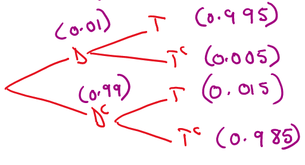

- every level of the tree adds up to 1

### Example 2

65% of the email sent to my account is spam. If an email is actually spam, the spam filter will correcltly identify it 80% of the time. If the email is not spam, the filter still tags it as spam 4% of the time. Given that a message has been tagged as spam, what is the probability that it is actually a spam? Given that a message makes it through the filter without being tagger as a spam, what is the probability that it really isn’t spam?

- looking at performance of the filter

Let S : spam , and C : spam filter tags as spam

P(S) = 0.65 , P(C|S) = 0.8 , P(C|$S^C$) = 0.04

$P(S|C)=\frac{P(C|S)\times P(S)}{P(C|S\times P(S))]\times [P(C|S^C)\times P(S^C)]}$

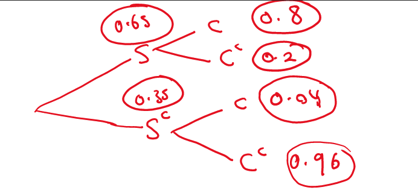

$\Rightarrow P(S|C)=\frac{0.8(0.65)}{[0.8(0.65)]+[(0.04)(0.35)]}=\frac{260}{267}\approx 0.9738$ (4 dp)

(4 dp)

### Extra Credit

- email before 10am Thur.
- will solve both on Thur.

**At a certain gas station, 40% of the customers use regular gas ($A_1$), 35% use plus gas ($A_2$), and 25% use premium ($A_3$). Of those customers using regular gas, only 30% fill their tanks (event B). If those customers using plus, 60% fill their tanks , whereas of those using premium, 50% fill their tanks.**

P($A_1$) = 0.4 , P($A_2$) = 0.35 , P($A_3$) = 0.25

P(B|$A_1$) = 0.30 , P(B|$A_2$) = 0.60 , P(B|$A_1$) = 0.50

**(a) What is the probability that the next customer will request plus gas and fill the tank?**

$P(A_2\cap B)=P(B|A_2)\times P(A_2)=0.60\times 0.35 = 0.21$

**(b) What is the probability that the next customer fills the tank?**

$$\begin{equation}\label{p fill tank}
\begin{split}
P(B) & = P(A|cap A_1)+P(A|cap A_2)+P(A|cap A_3)\\
& = [P(B|A_1)\cdot P(A_1)]+[P(B|A_2)\cdot P(A_2)]+[P(B|A_3)\cdot P(A_3)]\\
& = 0.455
\end{split}
\end{equation}$$

**(c) If the next customer fills the tank, what is the probability taht regular gas is requested? Plus? Premium?**

$P(A_1|B)=\frac{P(A_1\cap B)}{P(B)}=\frac{P(B|A_1)\cdot P(A_1)}{P(B)}=\frac{24}{91}\approx 0.264$ (3 d.p.)

$P(A_2|B)=\frac{P(A_2\cap B)}{P(B)}=\frac{P(B|A_2)\cdot P(A_2)}{P(B)}=\frac{6}{13}\approx 0.462$ (3 d.p.)

$P(A_3|B)=\frac{P(A_3\cap B)}{P(B)}=\frac{P(B|A_3)\cdot P(A_3)}{P(B)}=\frac{25}{91}\approx 0.275$ (3 d.p.)

**Part 2 : Prove that $^{n+1}C_k=^{n}C_k+^nC_{k-1}$ is true. (not exzactly what is in the book)**

Proof : $^{n+1}C_k=^{n}C_k+^nC_{k-1}$

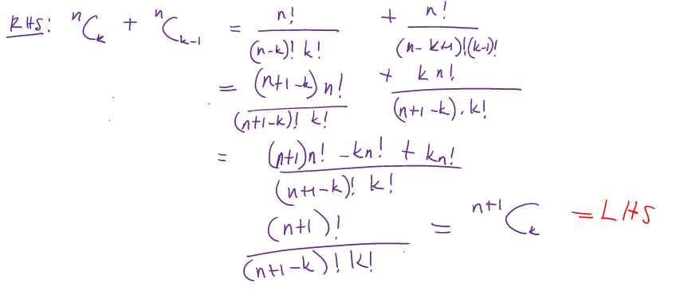

### Summary

- Bayes’ Rule : $P(A_i|B)=\frac{P(A_i\cap B)}{P(B)}=\frac{P(B|A_i)\times P(A_i)}{\sum\limits_{j=1}^{k}[P(B|A_j)\times P(A_j)]}$
- tree diagrams

### To Do

- fill in gaps in todays notes (complete)
- extra credit (complete)

# W3-D6 : Thur. Oct. 14th, 2021

- extra credit

### Chapter 3 : Random Variables & Probability Distributions

For a given sample space of en experiment, S, a **random variable** (typically denoted X or Y, capital letters) is any rule that associates a real number with each outcome in S.

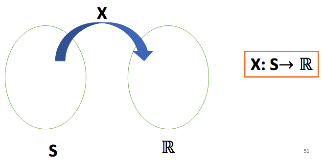

### Example

Flip a coin three times. Let X = {The number of heads}

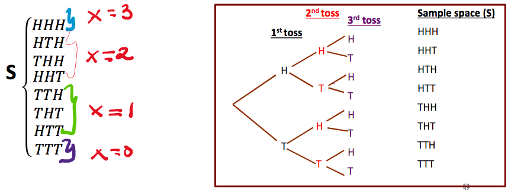

### Types of Random Variables

**Discrete** : A random variable whose possible values either consititue a finite set or one whose range is countabley infinite (count).

- example : the number of studnets in a class, results of rolling a two on a 6-sided die

**Contnuous** : A random variable whose range is an interval on the number line (measure). Uncountably infinite.

- example : A dog’s weight, a person’s height, waiting time for a flight, etc.

### Probability Distribution

**Probability Distribution** : A description of how the total probability 1 is distributed among the various possible values of the ranom varible X.

- note : each possible value of the random variable X is assigned a probability. The sum of all the probabilites for the various possible values of X is equal to 1.

For **discrete** random variables, this is called the **Probability mass function (pmf)**

- $\forall x$ the pmf is defined as $p(x)=P(X=x)$

Properties of the pmf :

1. $0\leq p(x)\leq1$
2. $\sum\limits_{x\in S}p(x)=1$

For **continuous** random variables, this is called the **Probability density function (pdf)**

- $\forall x$ the pdf is defined as $f(x)=P(a\leq X\leq b)=\int_a^bf(x)dx$

Properties of pdf :

1. $f(x)\geq0\forall x$
2. $\int_{-\infty}^{\infty}f(x)dx=1$

### Relevant Properties

1. $P(X=a)=\int_a^af(x)dx=0\forall a$.
2. $P(a\leq X\leq b) = P(X=a)+P(a<X<b)+P(X=b)=P(a<X<b)$
3. $P(a\leq X\leq b)=P(a<X\leq b)=P(a\leq X <b)=P(a<X<b)$

This is only true for continuous distribution

### Example 1 - Discrete

Flip a coin three times. Let X = {The number of heads}

|  | V1 | V2 | V3 | V4 |
| --- | --- | --- | --- | --- |
| X | 0 | 1 | 2 | 3 |
| p.x | 1/8 | 3/8 | 3/8 | 1/8 |

$$p(x) = \begin{cases}
1/8 & \text{if }x = 0\\
3/8 & \text{if }x = 1\\
3/8 & \text{if }x = 2\\
1/8 & \text{if }x = 3\\
0 & \text{otherwise} \\
\end{cases}$$

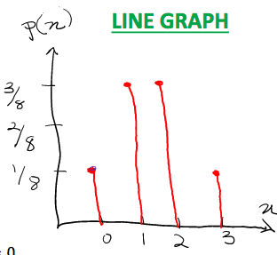

### Example 2

A car dealer has 30 cars available for immediate sale, of which 10 are classified as compact cars. Three customers arrive and buy cars. Define the random variable X to be the number of compact cars sold.

1. What is the pmf of X?

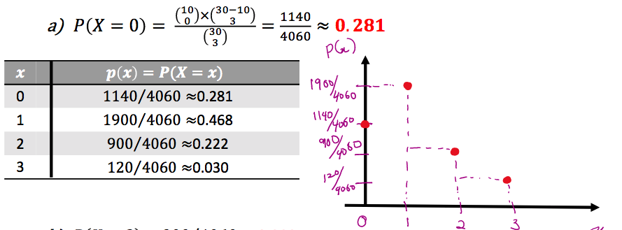

2. What is the probability exactly 2 cars are purchased?

$P(X=2)=\frac{900}{4060}$

3. What is the probability less than 2 compact cars are purchased?

$P(X<2)=P(X=0)+P(X=1)=0.281+0.468\approx 0.749$

### Extra Credit Problem

If A and B are independent events, show that - A and $\overline{B}$ are also independent. - Are $\overline{A}$ and $\overline{B}$ independent?

For A and B $\rightarrow$ independent then, - $P(A|B)=P(A)$ - $P(B|A)=P(B)$ - $P(A\cap B)=P(A)P(B)$

1. Proof that A, and B’ are Independent

$$\begin{equation}\label{A and B' are independent }
\begin{split}
P(A|\overline{B}) & = \frac{P(A\cap \overline{B})}{P(\overline{B})}\\
& = \frac{P(\overline{B}|A)P(A)}{P(\overline{B})}\\
& = \frac{[1-P(B|A)]P(A)}{P(\overline{B})}\\
& = \frac{[1-P(B)]P(A)}{P(\overline{B})}\\
& = \frac{[P(\overline{B})]P(A)}{P(\overline{B})}\\
& = P(A)
\end{split}
\end{equation}$$

Therefore $P(A|\overline{B})=P(A)$. QED.

2. Proof that A’ and B’ are independent

$$\begin{equation}\label{A' and B' are independent }
\begin{split}
P(\overline{A}|\overline{B}) & = \frac{P(\overline{A}\cap \overline{B})}{P(\overline{A})}\\
& = \frac{P(\overline{B}|\overline{A})P(\overline{B})}{P(\overline{A})}\\
& = \frac{[1-P(A|\overline{B})]P(\overline{B})}{P(\overline{A})}\\
& = \frac{[1-P(A)]P(\overline{B})}{P(\overline{A})}\\
& = \frac{[P(\overline{A})]P(\overline{B})}{P(\overline{A})}\\
& = P(B)
\end{split}
\end{equation}$$

Therefore $P(\overline{B}|\overline{A})=P(B)$. QED.

### Summary

- discrete random variables (countable)
  - pmf
- continuous random variables (measureable)
  - pdf

### To Do

- compare hw1 to solutions (complete)
- HW2 (complete)

# W4-D7 : Tues. Oct. 19th, 2021

- review
  - random variable : associates a real number with each outcome in S.
  - support : the set of possible values for the random variable
  - discrete : finite and countable set
  - countinuous : unaccountably infinite and measurable
  - probability distribution : description of how probability is distributed among the various possible values of the random variable X.
  - probability mass function (pmf) : for discrete rv (sum = 1)
  - probability density function (pdf) : for continuous rv (integral = 1)
    - integrating area under the curve
  - relevant properties (continuous rv) : P(X=a)=0, because integral needs range

### Example 1

**The current in a certain circuit as measured by an ammeter is a continuous r.v. X with the following pdf:**

$$f(x) = \begin{cases}
0.075x+0.2 & \text{for }3\leq x\leq 5 \\
0 & \text{otherwise} \\
\end{cases}$$

**(1) Sketch the graph of $f(x)$**

$f(3)=0.075(3)+0.2=0.425$ $f(5)=0.075(5)+0.2=0.575$

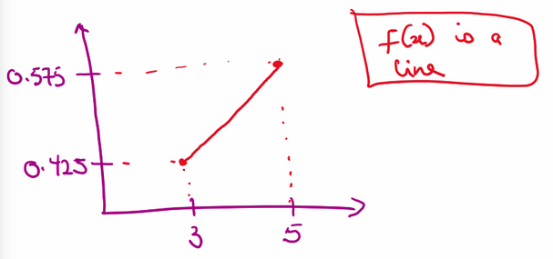

**(2) Calculate $P(X\leq P)$**

$P(x\leq4)=P(3\leq X\leq 4)=\int_3^4(0.075x+0.2)dx=0.4625$

**(3) How does the probability above compare to $P(X<4)$?**

For coninuous random variable $P(X<4)=P(X\leq 4)=0.4625$

**(4) Calculate $P(4.5<X)$.**

$P(4.5<x)=P(4.5< X< 5)=\int_{4.5}^5(0.075x+0.2)dx=0.278125$

### Example 2

**Suppose the time between injury accidents in a nuclear power plant (in days) is a random variable that has pdf :**

$$f(x) = \begin{cases}
\frac{1}{3}e^{-y/3} & y>0 \\
0 & y\leq 0 \\
\end{cases}$$

**(a) Verify that the function is a pdf.**

1. $f(y)\geq0$ for all y

$y\geq 0 \rightarrow [0,\infty)$

$\lim\limits_{n\rightarrow \infty}f(n)=\frac{1}{3}(0)=0$

2. $\int_0^{\infty}f(y)dy=1$

$\int_0^\infty f(y)dy=\int_0^\infty \frac{1}{3}e^{-y/3}dy=\frac{1}{3}[(-3)(0-1)]=1$

$\therefore f(x)$ is a valid pdf.

**(b) What is the probability that the time between accidnets is between 2 and 5 days?**

$P(2<X<5)=\int_2^5\frac{1}{3}e^{-y/3}dy=(-1)[e^{-5/3}-e^{-2/3}]\approx 0.325$ 3 d.p.

**(c) Find the CDF of Y.**

$$F(y) = \begin{cases}
0 & y<0 \\
1-e^{-y/3} & y\geq 0
\end{cases}$$

### Cummulative Distribution Functions (CDF)

The cumulative distribution function (CDF) for a random variable X with PMF $p(x)$ is defined for every number $x$ by
$$F(X)=P(X\leq x)\quad\text{for}-\infty<x<\infty$$

F(x) is a valid CDF if and only if: - $F(X)\geq 0$ - $F(X)\leq 1$ - F(x) is a non-decreasing funciton [That is if $x_1$, $x_2$ are two values such that and $x_1\leq x_2$, then $F(x_1)<F(x_2)$

### Relationship between CDFs and PMFs

For any discrete random variable X

> $$F(x)=\sum\limits_{x_i\leq x}p(x_i)\Leftrightarrow p(x_i)=F(x_i)-F(x_{i-1})\quad\text{for }i=2,3,...$$

and

> $F(x_1)=p(x_1)$

### Cummulative Distibution Function (CDF)

- The **cumulative distribution function** (cdf) for a continuous random variable X is defined as :

> $$F(x)=P(X\leq x)=\int_{-\infty}^xf(t)dt$$
- Suppose taht X is a continuous random variable, then for any number *a*

> $$P(X>a)=1-F(a)$$

and for any two number *a* and *b*, such that $a<b$.

> $$P(a\leq X\leq b)=F(b)-F(a)$$

### Obtaining pdf from cdf

If X is a continuous rv with pdf $f(x)$ and cdf $F(x)$, then at every x at which the derivative *x* exists, $f(x)=F'(x)$.

- Example :

$$F(x) = \begin{cases}
0 & x<0 \\
\frac{1}{4}x^2 & 0\leq x<2 \\
1 & 2<x
\end{cases}$$

For $0\leq 2<2$ : $f(x)=F'(x)=\frac{d}{dx}(\frac{1}{4}x^2)=\frac{1}{4}2x=\frac{1}{2}x$

For $x<0$ : $f(x)=F'(x)=0$

For $x>2$ : $f(x)=F'(x)=0$

### Summary

- pdf (probability d.f.)
- cdf (cummulative d.f.)
  - $F(x)=P(X\leq x)=\int_{-\infty}^xf(t)dt$
  - $P(X>a)=1-F(a)$
  - $P(a\leq X\leq b)=F(b)-F(a)$
- obtainding pdf from cdf : $f(x)=F'(x)$

### To Do

- finish today’s notes (complete)

# W4-D8 : Thur. Oct. 21st, 2021

- no graphing calculators on tests, but R is okay?
- review
  - random variable : associates a real number with an outcome in S
  - Discrete : rv are a finite set with a countably infinite range
  - Continuous : rv whose range is an interval on the number line, and uncountably infinite.
  - probability distribution : how the total probability 1 is distributed amoung rv X.
  - PMF : for discrete rv (sum)
  - PDF : for continuous rv (integral)
  - CDF : rv X with PMF p(x)
    - $f(x)=F'(x)$ with PDF $f(x)$ and CDF $F(X)$.
    - PDF is derivative of CDF
    - CDF is integral of PDF

### Example 2

Consider the pdf below:

$$f(x) = \begin{cases}
\frac{1}{2}x & 0\leq x <2\\
0 & \text{otherwise}\\
\end{cases}$$

**(a) Obtain the cdf for any number between 0 and 2.**

$$F(x) = \begin{cases}
0 & x<0\\
\frac{1}{4}x^2 & 0\leq x<2\\
1 & x\geq 2
\end{cases}$$

- take note that 0 is at the top and 1 is at the bottom of the CDF function

**(b) Using the cdf, find $P(X\leq \frac{4}{5})$**

$F(x)=P(X\leq x)$

$P(X\leq \frac{4}{5})=F(\frac{4}{5})=\frac{1}{4}(\frac{4}{5})^2=\frac{4}{25}=0.16$

- if use cdf route only integrate once and then plug in probabilities

**(c) Using the pdf, find $P(X\leq \frac{4}{5})$**

$P(X\leq \frac{4}{5})=P(0\leq X\leq \frac{4}{5})=\int_0^{\frac{4}{5}}\frac{1}{2}xdx=\frac{4}{25}$

- if use the pdf need to set up integral

**(d) Using the cdf, find $P(X> \frac{6}{5})$**

$P(X> \frac{6}{5})=1-P(x\leq \frac{6}{5})=1-F(\frac{6}{5})=1-\frac{1}{4}(\frac{6}{5})^2=\frac{64}{100}=0.64$

**(e) Using the cdf, find $P(\frac{1}{2}<X< \frac{5}{2})$**

$P(\frac{1}{2}<X< \frac{5}{2})=F(\frac{5}{2})-F(\frac{1}{2})=1-\frac{1}{4}(\frac{1}{2})^2=\frac{15}{16}$

### Expected Values - Discrete

Let X be a discrete random variable with set of possible values D and pmf *p(x)*.

- The mean or expected value of X is
  $$E(X)=\mu_X=\sum\limits_{X \in D}xp(x)$$
- If a random variable *X* has a set of possible values *D* and pmf *p(x)*, then the expected value of any function *h(x)* is
  $$E[h(x)]=\sum_{x\in D}h(x)p(x)$$

### Example

Flip a coin three times. X = {The number of heads}. Given $Y=3X+7$, calculate the expected value E(X), E(Y).

[output not shown]

$E(X)=\sum\limits_{x=1}^4xp(x)=0(\frac{1}{8})+1(\frac{3}{8})+2(\frac{3}{8})+3(\frac{1}{8})=\frac{3}{2}$

### Example

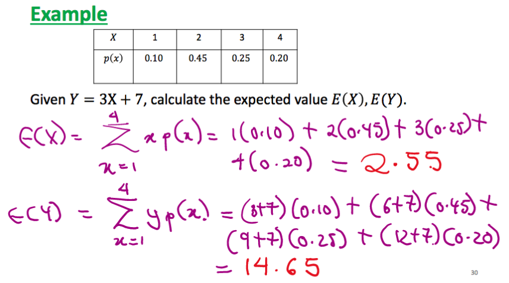

### Properties of the expected value

- Let a be some constant, X is a rv $E(aX)=aE(X)$
- Let X and Y be two random variables, $E(X+Y)=E(X)+E(Y)$.
- Let b be some constant E(b)

**Compounding :** $E(aX+bY+c)=aE(X)+bE(Y)+c$

### Variance of a random variable

- Let X have pmf $p(x)$ and expected value $\mu_X$. Then the **variance** of X is

$$\sigma^2(X)=V(X)=E[(X-\mu_x)^2]=\sum_{x\in D}(x-\mu_x)^2p(x)$$

- By construction the **standard deviation** is defined

$$\sigma (X)=\sqrt{\sigma^2(X)}=\sqrt{V(X)}$$

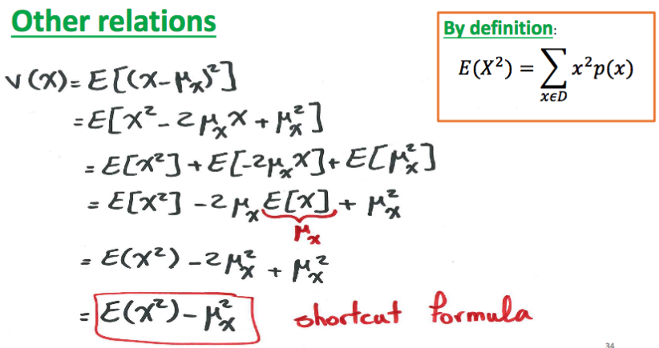

### Example

Calculate $V(X)$ for using the shortcut formula.

|  | V1 | V2 | V3 | V4 |
| --- | --- | --- | --- | --- |
| X | 1.0 | 2.00 | 3.00 | 4.0 |
| p.x | 0.1 | 0.45 | 0.25 | 0.2 |

$V(X)=f(x^2)-\mu_x^2$

$f(x^2)=\sum\limits_{x=1}^4x^2p(x)=7.35$

$\Rightarrow V(X)=7.35-2.55^2=0.8475$

### Variance of a function

$$V[(h(X)]=E[(h(X)-\mu_{xh(x)})^2]=\sum_{x\in D}(h(x)-\mu_{h(x)})^2p(x)$$
**Properties of Variance**

- Let a be some constant, X is a RV $V(aX)=a^2V(X)$ .
- Let b be some constant, then $V(b)=0$.

### Summary

- Expected Value
- Variance

**Additional Notes**

- monday will cover continuous version of this (integrating instead of summing), and then will be good for the midterm
- MIDTERM NEXT WEEK!!!! (Chapters 1-3)

### To Do

- finish todays notes (complete)
- do practice problems from notes (1 hour : complete)
- practice problems from HW 1 (1 hour : complete)
- practice book problems from chapter 2

# W5-D9 : Tues. October 26, 2021

### To Do

- practice problems from HW 2
- practice problems from chapter 3

# W5-D10 : Thur. Octorber 28, 201